# Project 1: Wrangling, Exploration, Visualization

SDS322E

## Data Wrangling, Exploration, Visualization

### Nitya Kodali nk9723

### Introduction

The datasets that I used are cousin_marriage and drinks. I thought that the drinks dataset was interesting and wanted to find something that had a countries variable to join the two datasets. The cousin_marriage dataset is about a taboo topic so I wanted to see if there was a correlation between alcohol and cousin marriage. I also really liked the articles that were written about the datasets, by Mona Chalabi. I found the datasets and articles tied to them through the fivethirtyeight package. The cousin marriage dataset had only two variables, the country and the percent of marriages that are cosanguineous. The drinks dataset had five variables, the country, the servings of beer, sprits, and wine per person, and the total litres of pure alcohol per person (per year). I doubt that there will be any significant associations between drinking and cousin marriage, but I am curious to see if there is one. If there is an association to cousin marriage, I believe it will not matter the type of alcohol (beer/spirit/wine) but just the total liters.

```r
library(fivethirtyeight)
data1 <- drinks
data2 <- cousin_marriage
```

### Tidying: Reshaping

Since my datasets were already tidy, I showed that I can use pivot_longer and pivot_wider with the drinks dataset (data1). I used the columns related to beer, wine, and spirit servings to pivot my dataset longer and assigned this long dataset to “untidy”. Then, I pivoted the untidy dataset wider to convert the dataset back to it’s original tidy form (retidied).

```r
library(tidyverse)
untidy <- data1 %>% pivot_longer(2:4, names_to = "serving_type",
    values_to = "count")
head(untidy)
```

```
## # A tibble: 6 x 4
##   country     total_litres_of_pure_alcohol serving_type    count
##   <chr>                              <dbl> <chr>           <int>
## 1 Afghanistan                          0   beer_servings       0
## 2 Afghanistan                          0   spirit_servings     0
## 3 Afghanistan                          0   wine_servings       0
## 4 Albania                              4.9 beer_servings      89
## 5 Albania                              4.9 spirit_servings   132
## 6 Albania                              4.9 wine_servings      54
```

```r
data1 <- untidy %>% pivot_wider(names_from = "serving_type",
    values_from = "count")
head(data1)
```

```
## # A tibble: 6 x 5
##   country      total_litres_of_pure… beer_servings spirit_servings wine_servings
##   <chr>                        <dbl>         <int>           <int>         <int>
## 1 Afghanistan                    0               0               0             0
## 2 Albania                        4.9            89             132            54
## 3 Algeria                        0.7            25               0            14
## 4 Andorra                       12.4           245             138           312
## 5 Angola                         5.9           217              57            45
## 6 Antigua & B…                   4.9           102             128            45
```

### Joining/Merging

```r
data1 %>% summarize(n())
```

```
## # A tibble: 1 x 1
##   `n()`
##   <int>
## 1   193
```

```r
data2 %>% summarize(n())
```

```
## # A tibble: 1 x 1
##   `n()`
##   <int>
## 1    70
```

```r
data1 %>% summarize(n_distinct(country))
```

```
## # A tibble: 1 x 1
##   `n_distinct(country)`
##                   <int>
## 1                   193
```

```r
data2 %>% summarize(n_distinct(country))
```

```
## # A tibble: 1 x 1
##   `n_distinct(country)`
##                   <int>
## 1                    70
```

```r
data1 %>% anti_join(data2, by = "country")
```

```
## # A tibble: 126 x 5
##    country      total_litres_of_pur… beer_servings spirit_servings wine_servings
##    <chr>                       <dbl>         <int>           <int>         <int>
##  1 Afghanistan                   0               0               0             0
##  2 Albania                       4.9            89             132            54
##  3 Andorra                      12.4           245             138           312
##  4 Angola                        5.9           217              57            45
##  5 Antigua & B…                  4.9           102             128            45
##  6 Armenia                       3.8            21             179            11
##  7 Austria                       9.7           279              75           191
##  8 Azerbaijan                    1.3            21              46             5
##  9 Bahamas                       6.3           122             176            51
## 10 Barbados                      6.3           143             173            36
## # … with 116 more rows
```

```r
data2 %>% anti_join(data1, by = "country")
```

```
## # A tibble: 3 x 2
##   country         percent
##   <chr>             <dbl>
## 1 Great Britain       0.4
## 2 The Netherlands     0.2
## 3 United States       0.2
```

```r
data2 <- data2 %>% mutate(country = str_replace(country, "United States",
    "USA")) %>% mutate(country = str_replace(country, "The Netherlands",
    "Netherlands")) %>% mutate(country = str_replace(country,
    "Great Britain", "United Kingdom"))
data1 %>% inner_join(data2, by = "country")
```

```
## # A tibble: 70 x 6
##    country  total_litres_of… beer_servings spirit_servings wine_servings percent
##    <chr>               <dbl>         <int>           <int>         <int>   <dbl>
##  1 Algeria               0.7            25               0            14    22.6
##  2 Argenti…              8.3           193              25           221     0.5
##  3 Austral…             10.4           261              72           212     0.5
##  4 Bahrain               2              42              63             7    44.4
##  5 Banglad…              0               0               0             0    10.5
##  6 Belgium              10.5           295              84           212     1.1
##  7 Bolivia               3.8           167              41             8     1.7
##  8 Brazil                7.2           245             145            16     4.3
##  9 Burkina…              4.3            25               7             7    65.8
## 10 Canada                8.2           240             122           100     1.5
## # … with 60 more rows
```

```r
joined_data <- data1 %>% inner_join(data2, by = "country")
```

### Wrangling

```r
library(stringr)
joined_data <- joined_data %>% mutate(percentclass = case_when(percent >
    5 ~ "Greater than 5 percent", TRUE ~ "Less than 5 percent"))
joined_data %>% mutate(servings.total = wine_servings + beer_servings +
    spirit_servings)
```

```
## # A tibble: 70 x 8
##    country total_litres_of… beer_servings spirit_servings wine_servings percent
##    <chr>              <dbl>         <int>           <int>         <int>   <dbl>
##  1 Algeria              0.7            25               0            14    22.6
##  2 Argent…              8.3           193              25           221     0.5
##  3 Austra…             10.4           261              72           212     0.5
##  4 Bahrain              2              42              63             7    44.4
##  5 Bangla…              0               0               0             0    10.5
##  6 Belgium             10.5           295              84           212     1.1
##  7 Bolivia              3.8           167              41             8     1.7
##  8 Brazil               7.2           245             145            16     4.3
##  9 Burkin…              4.3            25               7             7    65.8
## 10 Canada               8.2           240             122           100     1.5
## # … with 60 more rows, and 2 more variables: percentclass <chr>,
## #   servings.total <int>
```

```r
str_detect(joined_data$percentclass, paste("G.", collapse = "|"))
```

```
##  [1]  TRUE FALSE FALSE  TRUE  TRUE FALSE FALSE FALSE  TRUE FALSE FALSE FALSE
## [13] FALSE FALSE FALSE FALSE FALSE FALSE  TRUE FALSE FALSE  TRUE FALSE FALSE
## [25]  TRUE  TRUE  TRUE  TRUE FALSE  TRUE FALSE  TRUE  TRUE  TRUE  TRUE  TRUE
## [37]  TRUE  TRUE FALSE  TRUE FALSE  TRUE FALSE  TRUE  TRUE FALSE FALSE FALSE
## [49] FALSE  TRUE  TRUE FALSE FALSE FALSE FALSE  TRUE  TRUE FALSE  TRUE  TRUE
## [61]  TRUE  TRUE  TRUE FALSE  TRUE FALSE FALSE  TRUE FALSE  TRUE
```

```r
joined_data %>% filter(total_litres_of_pure_alcohol >= 5) %>%
    dplyr::select(-percent) %>% arrange(desc(beer_servings))
```

```
## # A tibble: 30 x 6
##    country total_litres_of… beer_servings spirit_servings wine_servings
##    <chr>              <dbl>         <int>           <int>         <int>
##  1 Czech …             11.8           361             170           134
##  2 Venezu…              7.7           333             100             3
##  3 Ireland             11.4           313             118           165
##  4 Belgium             10.5           295              84           212
##  5 Panama               7.2           285             104            18
##  6 Spain               10             284             157           112
##  7 Sloven…             10.6           270              51           276
##  8 Austra…             10.4           261              72           212
##  9 Nether…              9.4           251              88           190
## 10 USA                  8.7           249             158            84
## # … with 20 more rows, and 1 more variable: percentclass <chr>
```

```r
joined_data %>% group_by(percentclass) %>% summarize(n())
```

```
## # A tibble: 2 x 2
##   percentclass           `n()`
##   <chr>                  <int>
## 1 Greater than 5 percent    34
## 2 Less than 5 percent       36
```

Here, I used mutate to create a categorical variable as I didn’t have any. I also use the function case_when inside of mutate. I then used mutate to demonstrate creating a new variable that is the function of other variables. I also used stringr with regex to detect all observations with greater than 5 percent for their percentclass variable. I also explored my data using all six dplyr functions.

```r
library(gt)
MedAbsDev <- function(x) median(abs(x - median(x)))
joined_data %>% summarize(mean = mean(beer_servings), sd = sd(beer_servings),
    min = min(beer_servings), max = max(beer_servings), MedAbsDev = MedAbsDev(beer_servings))
```

```
## # A tibble: 1 x 5
##    mean    sd   min   max MedAbsDev
##   <dbl> <dbl> <int> <int>     <dbl>
## 1  108.  107.     0   361      62.5
```

```r
joined_data %>% summarize(mean = mean(spirit_servings), sd = sd(spirit_servings),
    min = min(spirit_servings), max = max(spirit_servings), MedAbsDev = MedAbsDev(spirit_servings))
```

```
## # A tibble: 1 x 5
##    mean    sd   min   max MedAbsDev
##   <dbl> <dbl> <int> <int>     <dbl>
## 1  68.5  59.9     0   215      53.5
```

```r
joined_data %>% summarize(mean = mean(wine_servings), sd = sd(wine_servings),
    min = min(wine_servings), max = max(wine_servings), MedAbsDev = MedAbsDev(wine_servings))
```

```
## # A tibble: 1 x 5
##    mean    sd   min   max MedAbsDev
##   <dbl> <dbl> <int> <int>     <dbl>
## 1  62.3  96.2     0   370         8
```

```r
joined_data %>% summarize(mean = mean(total_litres_of_pure_alcohol),
    sd = sd(total_litres_of_pure_alcohol), min = min(total_litres_of_pure_alcohol),
    max = max(total_litres_of_pure_alcohol), MedAbsDev = MedAbsDev(total_litres_of_pure_alcohol))
```

```
## # A tibble: 1 x 5
##    mean    sd   min   max MedAbsDev
##   <dbl> <dbl> <dbl> <dbl>     <dbl>
## 1  4.60  3.88     0  11.8      3.45
```

```r
joined_data %>% group_by(percentclass) %>% summarize(n = n()) %>%
    gt %>% tab_header(title = md("**Categorical Variable**"))
```

**Categorical Variable**

| percentclass | n |
| --- | --- |
| Greater than 5 percent | 34 |
| Less than 5 percent | 36 |

```r
joined_data %>% summarize_all(function(x) sum(is.na(x)))
```

```
## # A tibble: 1 x 7
##   country total_litres_of… beer_servings spirit_servings wine_servings percent
##     <int>            <int>         <int>           <int>         <int>   <int>
## 1       0                0             0               0             0       0
## # … with 1 more variable: percentclass <int>
```

Here, I computed summary statistics for all my numeric variables, using unique functions inside of summarize. One of the functions(MedAbsDev) was defined by me and then used. I also checked my categorical variable counts for each level. This count was portrayed using the package gt.

```r
joined_data %>% group_by(percentclass) %>% summarize(mean = mean(beer_servings),
    sd = sd(beer_servings), min = min(beer_servings), max = max(beer_servings),
    MedAbsDev = MedAbsDev(beer_servings))
```

```
## # A tibble: 2 x 6
##   percentclass            mean    sd   min   max MedAbsDev
##   <chr>                  <dbl> <dbl> <int> <int>     <dbl>
## 1 Greater than 5 percent  18.6  20.0     0    77      10.5
## 2 Less than 5 percent    192.   83.3    52   361      60.5
```

```r
joined_data %>% group_by(percentclass) %>% summarize(mean = mean(spirit_servings),
    sd = sd(spirit_servings), min = min(spirit_servings), max = max(spirit_servings),
    MedAbsDev = MedAbsDev(spirit_servings))
```

```
## # A tibble: 2 x 6
##   percentclass            mean    sd   min   max MedAbsDev
##   <chr>                  <dbl> <dbl> <int> <int>     <dbl>
## 1 Greater than 5 percent  33.8  49.3     0   202       6.5
## 2 Less than 5 percent    101.   50.1    12   215      35.5
```

```r
joined_data %>% group_by(percentclass) %>% summarize(mean = mean(wine_servings),
    sd = sd(wine_servings), min = min(wine_servings), max = max(wine_servings),
    MedAbsDev = MedAbsDev(wine_servings))
```

```
## # A tibble: 2 x 6
##   percentclass             mean     sd   min   max MedAbsDev
##   <chr>                   <dbl>  <dbl> <int> <int>     <dbl>
## 1 Greater than 5 percent   5.03   7.23     0    31         1
## 2 Less than 5 percent    116.   110.       1   370        98
```

```r
joined_data %>% group_by(percentclass) %>% summarize(mean = mean(total_litres_of_pure_alcohol),
    sd = sd(total_litres_of_pure_alcohol), min = min(total_litres_of_pure_alcohol),
    max = max(total_litres_of_pure_alcohol), MedAbsDev = MedAbsDev(total_litres_of_pure_alcohol))
```

```
## # A tibble: 2 x 6
##   percentclass            mean    sd   min   max MedAbsDev
##   <chr>                  <dbl> <dbl> <dbl> <dbl>     <dbl>
## 1 Greater than 5 percent  1.61  2.12   0     9.1       0.8
## 2 Less than 5 percent     7.43  2.92   1.5  11.8       2.8
```

I then grouped by the categorical variable and reran my summary statistics.

Overall, my results showed that there was indeed a correlation between the total pure alcohol in liters per person per year and the rate of cousin marriage in the country. This difference in averages across the percentclass definitely carried throughout the various types of servings (beer, spirit, wine).

### Visualizing

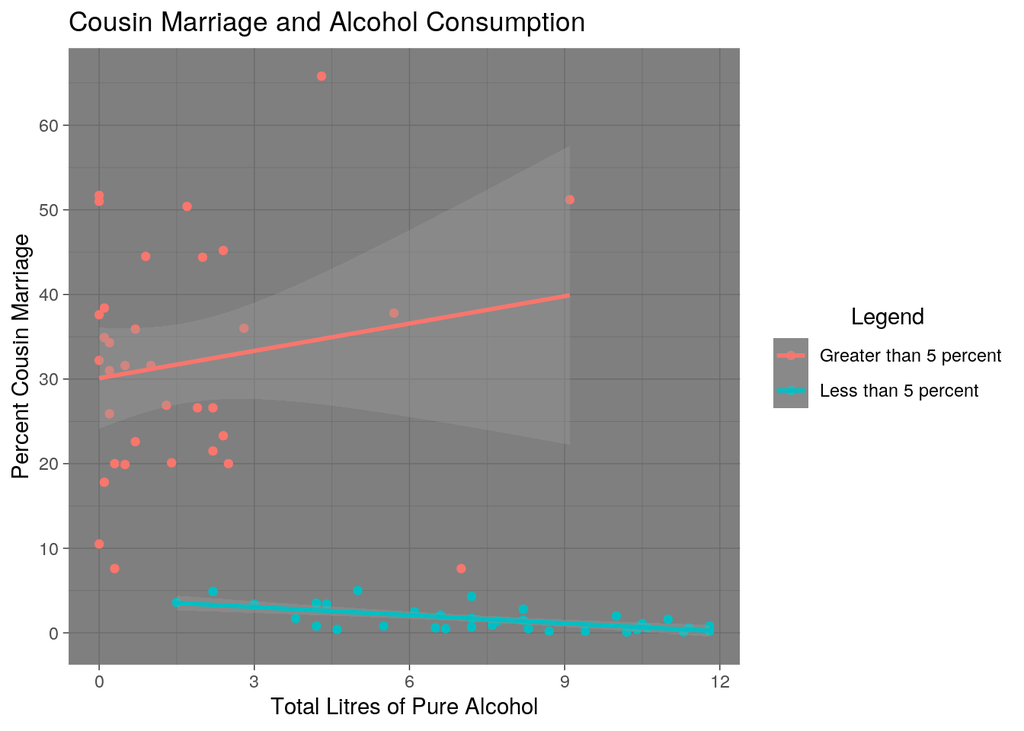

```r
joined_data %>% ggplot(aes(x = total_litres_of_pure_alcohol,
    y = percent, color = percentclass)) + geom_point() + geom_smooth(method = lm) +
    theme_dark() + scale_y_continuous(breaks = seq(0, 75, 10),
    name = "Percent Cousin Marriage") + scale_x_continuous(breaks = seq(0,
    15, 3), name = "Total Litres of Pure Alcohol") + theme(legend.title.align = 0.5) +
    labs(col = "Legend") + ggtitle("Cousin Marriage and Alcohol Consumption")
```

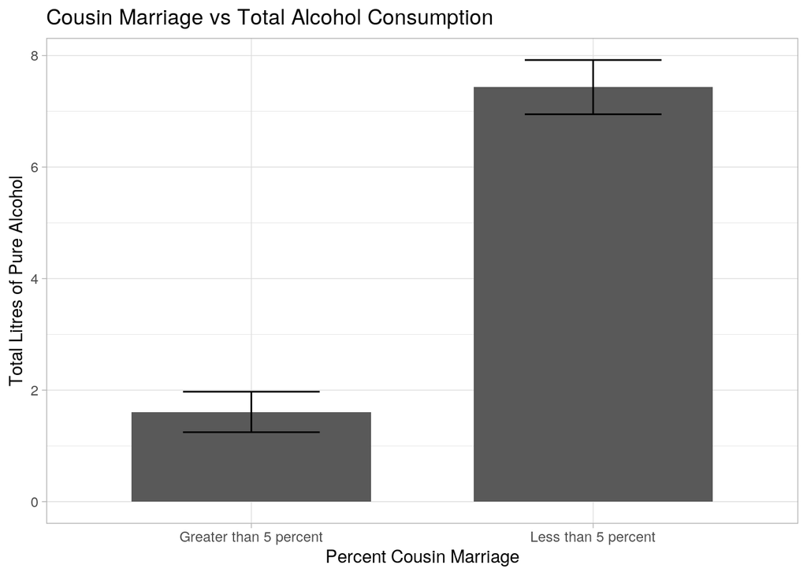

```r
joined_data %>% ggplot(aes(x = percentclass)) + geom_bar(aes(y = total_litres_of_pure_alcohol),
    stat = "summary", fun = mean, width = 0.7) + geom_errorbar(aes(y = total_litres_of_pure_alcohol),
    stat = "summary", fun.data = mean_se, width = 0.4) + theme_light() +
    labs(x = "Percent Cousin Marriage") + scale_y_continuous(breaks = seq(0,
    10, 2), name = "Total Litres of Pure Alcohol") + ggtitle("Cousin Marriage vs Total Alcohol Consumption")
```

Then, I made the same comparison of the countries with less than or greater than 5 percent of their marriages being consanguineous with the total liters of pure alcohol, but in bar chart form. This showed that there was a much higher total alcohol consumed for countries with less than 5 percent when compared with those that have greater than 5 percent.

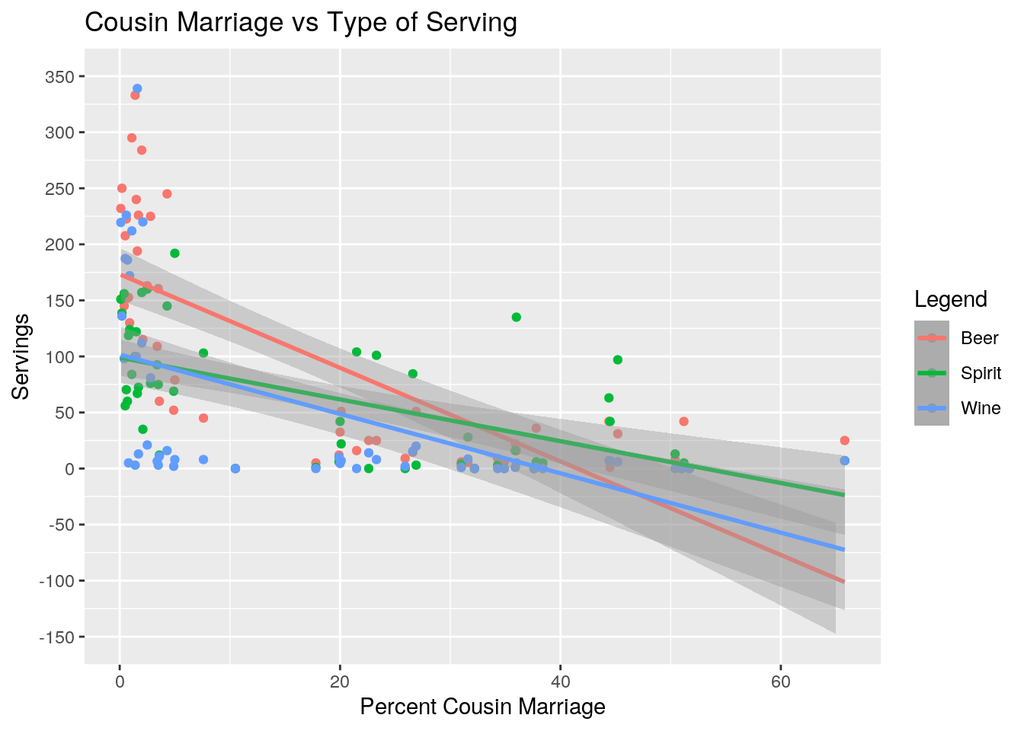

```r
colors <- c(Beer = "red", Wine = "blue", Spirit = "purple")
joined_data %>% ggplot(aes(x = percent)) + geom_point(aes(y = beer_servings,
    color = "Beer"), stat = "summary", fun = mean, size = 1.5) +
    geom_point(aes(y = spirit_servings, color = "Spirit"), stat = "summary",
        fun = mean) + geom_point(aes(y = wine_servings, color = "Wine"),
    stat = "summary", fun = mean) + geom_smooth(method = "lm",
    aes(y = beer_servings, color = "Beer")) + geom_smooth(method = "lm",
    aes(y = spirit_servings, color = "Spirit")) + geom_smooth(method = "lm",
    aes(y = wine_servings, color = "Wine")) + labs(x = "Percent Cousin Marriage",
    col = "Legend") + scale_y_continuous(breaks = seq(-150, 350,
    50), limits = c(-150, 350), name = "Servings") + ggtitle("Cousin Marriage vs Type of Serving") +
    theme_gray()
```

### Concluding Remarks

Overall this project helped me understand R much better, and it really felt like I was putting all the skills I have learned so far in this class into one project.